# STAT 440: Homework Assignment #2

Due: Thursday, Feb. 6 at 11:59pm on Canvas

Some of these exercises call for writing code. Please use R, and turn in your code along with your written work and any plots you are asked to produce. Just as you strive for clarity in your writing of language, try to write R code that is easy to read, in the sense that a knowledgeable user of R would be able to understand it easily.

You *may* choose to use LaTeX for your mathematics writing in your homework, in which case I recommend R Markdown as an easy way to combine text, mathematics, R code, and R output. But this is not required; you may choose to format your work however you find convenient, as long as you upload your assignment to Canvas as a single pdf document.

## Exercise 1

*This question is taken directly from the final exam for STAT 440 in FA 2023. The purpose of this question is to give you some practice with the style of questions you can expect on an exam.*

You are interested in simulating from a multivariate normal distribution in 4 dimensions. You start by simulating $Z\sim N_4(0, I_4)$, where $I_4$ denotes the $4\times 4$ identity matrix; this is easy to do because $Z$ consists merely of four i.i.d. standard normal variables stacked into a $4\times 1$ vector.

The goal is to left-multiply $Z$ by some $4\times 4$ matrix $M$ so that $MZ$ is a multivariate normal random vector with mean vector zero and covariance matrix
$$\Sigma = \begin{pmatrix} 30 & -10 & 4 & -20 \\ -10 & 30
& -20 & 4 \\
4 & -20 & 30 & -10 \\ -20 & 4 & -10 & 30
\end{pmatrix}.$$
Show how to use the eigendecomposition $\Sigma = VS V^\top$, given by the code below, to construct a matrix $M$ that can left-multiply $Z$ so that $MZ \sim N_4(0, \Sigma)$:

```r
Sigma <- matrix(c( 30, -10, 4, -20, -10, 30, -20, 4, 4, -20, 30, -10, -20, 4, -10, 30), 4, 4)
eigen(Sigma)
```

```
## eigen() decomposition
## $values
## [1] 64 36 16  4
##
## $vectors
##      [,1] [,2] [,3] [,4]
## [1,]  0.5  0.5  0.5 -0.5
## [2,] -0.5  0.5 -0.5 -0.5
## [3,]  0.5 -0.5 -0.5 -0.5
## [4,] -0.5 -0.5  0.5 -0.5
```

**Hint:** For any 4-column matrix $M$, the covariance matrix of $MZ$ equals $MM^\top$. You do not have to fully calculate the $M$ matrix; merely show how it can be calculated using the output shown.

### Answer

We want to show how we can use an eigen decomposition of matrix $\Sigma$ to construct a matrix M such that $MZ \sim N_4(0,\Sigma)$

First, we will store both the eigenvectors and eigenvalues in variables for future calculations.

```r
E <- eigen(Sigma)
Evecs <- E$vec
Evals <- E$val
```

We want to make it so that $MM^T = \Sigma$

Since the regular eigen decomposition of a matrix is in the form $VSV^T$ where $V$ is the matrix of eigenvectors and $S$ is a diagonal matrix containing the eigenvalues. We somehow need to decompose matrix $S$ even further so that it can be a part of both $V$ and $V^T$. Luckily the properties of a diagonal matrix say that we can split $S$ into two identical diagonal matrices that contain the square roots of the eigenvalues. The product of these matrices will result in the original matrix $S$.

```r
set.seed(12345)
M <- Evecs %*% diag(sqrt(Evals))

#Generate 10,000 of N_4(0,I) vectors
Z <- matrix(rnorm(4e3), nrow = 4, ncol = 1e4)
#Now for creating X by left multiplying by M:
X <- M %*% Z

cov(t(X))
```

```
##            [,1]       [,2]       [,3]       [,4]
## [1,]  29.346381 -10.088132   4.296048 -20.039659
## [2,] -10.088132  28.860626 -19.273202   4.956316
## [3,]   4.296048 -19.273202  28.389426 -10.113584
## [4,] -20.039659   4.956316 -10.113584  29.494266
```

```r
Sigma
```

```
##      [,1] [,2] [,3] [,4]
## [1,]   30  -10    4  -20
## [2,]  -10   30  -20    4
## [3,]    4  -20   30  -10
## [4,]  -20    4  -10   30
```

As we can see the random covariances generated by the M x Z matrix are approximately the same as the covariances in the original sigma matrix

## Exercise 2

*This question is taken directly from the final exam for STAT 440 in FA 2023. The purpose of this question is to give you some practice with the style of questions you can expect on an exam.*

Suppose that we have determined that the posterior density of $\theta$ is
$$f(\theta) = \left(\frac{81}{4}\right) \theta(1-\theta)^2 \quad\mbox{for
$\frac13 < \theta < 1$.}$$

We want to estimate the posterior expectation, or mean, of $\theta^2$, which we could write as $\mbox{E}_f(\theta^2)$. Suppose that $U_1, \ldots, U_n$ is an i.i.d. sample from $\mbox{Unif}(\frac13, 1)$.
Our approximation can be expressed as
$$\mbox{E}_f(\theta^2) \approx \frac1n \sum_{i=1}^n s(U_i)$$
for a particular function $s(U_i)$. What is $s(U_i)$? Show all your work.

### Answer

For this problem we will need to use importance sampling to find $s(U_i)$.

First, we will need to find the density function for $\mbox{Unif} \sim (\frac{1}{3}, 1)$ because we will need this to plug into the integral. $g(\theta) = \frac{1}{1-\frac{1}{3}} = \frac{3}{2}I_{\frac{1}{3}<x<1}$

We know that we can approximate the sample mean of $s(U_i)$ using $E_f(\theta^2)$. Then we can use the Monte Carlo approximation to find another summation that is approx. $E_f(\theta^2)$.

From Monte Carlo Integral Approximations:

$E_f[h(\theta)] = \int h(\theta)f(\theta)d\theta = \int h(\theta)\frac{f(\theta)}{g(\theta)}g(\theta)d\theta = E_g[h(\theta)\frac{f(\theta)}{g(\theta)}]$

From this we can derive that $E_f[h(\theta)] \approx \frac{1}{n}\sum_{i=1}^n h(U_i)\frac{f(U_i)}{g(U_i)}$ where $U_i$s are sampled from the above uniform distribution.

Then we can solve for the ratio in the summation:

$\frac{f(\theta)}{g(\theta)} = \frac{\frac{81}{4}\theta(1-\theta)^2 I_{\frac{1}{3}<x<1}}{\frac{3}{2}I_{\frac{1}{3}<x<1}} = \frac{27}{2}\theta(1-\theta)^2I_{\frac{1}{3}<x<1}$

Since we are estimating $E_f[\theta^2]$, we set $h(\theta)=\theta^2$

Then, we will have $E_f[\theta^2] \approx \frac{1}{n}\sum_{i=1}^n \theta_i^2 \frac{f(\theta_i)}{g(\theta_i)} = \frac{1}{n}\sum_{i=1}^n \frac{27}{2} \theta_i^3(1-\theta_i)^2$

Now since both expressions: $\frac{1}{n}\sum_{i=1}^n \frac{27}{2} \theta_i^3(1-\theta_i)^2$ and $\frac1n \sum_{i=1}^n s(U_i)$ are used to approximate $\mbox{E}_f(\theta^2)$, we can set them equal to each other.

Therefore, we get $s(U_i) = \frac{27}2 U_i^3(1-U_i)^2$

## Exercise 3

Take $\Sigma$ to be the $4\times4$ matrix defined in Exercise 1.

**Part (a)** Derive the correlation matrix that corresponds to $\Sigma$.

**Hint:** Recall that $\mbox{Cor}(X_i, X_j) = \mbox{Cov}(X_i, X_j) / \sqrt{\mbox{Var}(X_i)\mbox{Var}(X_j)}$ for any $i$ and $j$, even when $i=j$. Also, $\mbox{Var}(X_i) = \mbox{Cov}(X_i, X_i)$, so the variances are the diagonal elements of the covariance matrix.

**Part (b)** In `R`, construct the matrix $M$ from Exercise 1 and verify that $M M^\top=\Sigma$. Then write code to simulate 1000 random vectors $\mathbf(X)\sim N_4(\mathbf{\mu}, \Sigma)$, where $\mathbf{\mu} = (5, -5, 0, 8)^\top$. Calculate the sample mean vector and correlation matrix of your 1000 vectors.

To ensure that your results are exactly reproducible, use `set.seed(440)` just before your simulation.

**Hint:** With a bit of experimentation with matrix dimensions, you should be able to carry out Part (b) so that you produce a single $1000\times 4$ matrix, perhaps named `X`, so that `colMeans(X)` and `cor(X)` give the sample mean vector and correlation matrix.

**Part (c)** Produce a $4\times4$ scatterplot matrix of the vectors from Part (b) using the `pairs` function in `R`. As a check on the correctness of your work in Part (b), verify for yourself that the sample means are close to the corresponding coordinates of $\mu$ and that the correlations you found in Part (a) appear to agree with your scatterplots.

**Part (d)** Finally, load the `MASS` package in `R` and then use the `mvrnorm` function to produce 1000 random observations from $N_4(\mu,\Sigma)$. Calculate the sample mean and correlation matrix as well as the scatterplot matrix as in parts (b) and (c). Use `set.seed` in this part also, to ensure reproducibility.

### Answer

**Part a**

The correlation martix can be found by doing a simple calculation. First we will need to find the variance of each of the 4 variables in the multivariate distribution. This can be done by looking at the diagonal entries of the covariance matrix.

```r
variances <- diag(Sigma)
n <- nrow(Sigma)

corr_matrix <- matrix(0,n,n)

for (i in 1:n) {
  for (j in 1:n) {
    corr_matrix[i, j] <- Sigma[i, j] / sqrt((variances[i] * variances[j]))
  }
}

corr_matrix
```

```
##            [,1]       [,2]       [,3]       [,4]
## [1,]  1.0000000 -0.3333333  0.1333333 -0.6666667
## [2,] -0.3333333  1.0000000 -0.6666667  0.1333333
## [3,]  0.1333333 -0.6666667  1.0000000 -0.3333333
## [4,] -0.6666667  0.1333333 -0.3333333  1.0000000
```

**Part b**

we have already created the matrix M

```r
#check that m*m^T = sigma

M %*% t(M)
```

```
##      [,1] [,2] [,3] [,4]
## [1,]   30  -10    4  -20
## [2,]  -10   30  -20    4
## [3,]    4  -20   30  -10
## [4,]  -20    4  -10   30
```

```r
Sigma
```

```
##      [,1] [,2] [,3] [,4]
## [1,]   30  -10    4  -20
## [2,]  -10   30  -20    4
## [3,]    4  -20   30  -10
## [4,]  -20    4  -10   30
```

We can see that they are both the same.

```r
set.seed(440)
means <- c(5,-5,0,8)

Z <- matrix(rnorm(4000), nrow = 4, ncol = 1000)

# Transform to get X ~ N(mu, Sigma)
X <- t(M %*% Z) + matrix(means, nrow = 1000, ncol = 4, byrow = TRUE)

# Compute sample mean vector
sample_mean <- colMeans(X)

# Compute sample correlation matrix
sample_correlation <- cor(X)

# Print results
print("Sample Mean Vector:")
```

```
## [1] "Sample Mean Vector:"
```

```r
sample_mean
```

```
## [1]  5.25233142 -5.08887365 -0.02237312  7.80070054
```

```r
print("Sample Correlation Matrix:")
```

```
## [1] "Sample Correlation Matrix:"
```

```r
sample_correlation
```

```
##            [,1]       [,2]       [,3]       [,4]
## [1,]  1.0000000 -0.3187544  0.1212277 -0.6475852
## [2,] -0.3187544  1.0000000 -0.6579626  0.1041178
## [3,]  0.1212277 -0.6579626  1.0000000 -0.3050054
## [4,] -0.6475852  0.1041178 -0.3050054  1.0000000
```

**Part c**

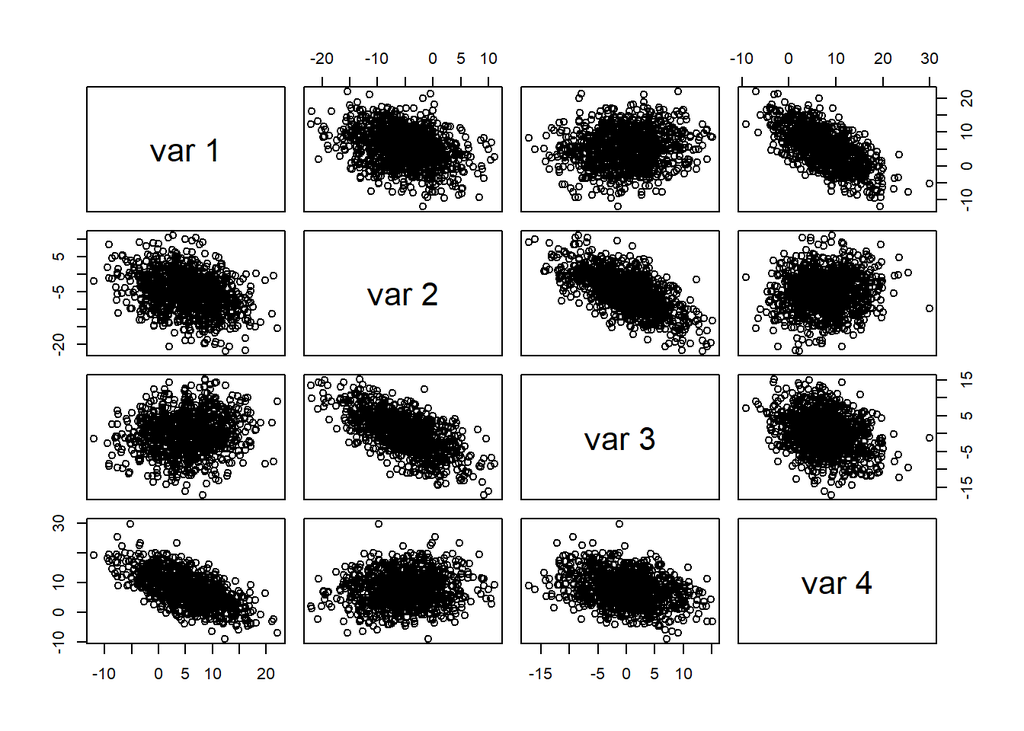

```r
pairs(X)
```

Looking at the plots, I can confirm that the paired plots follow both the mean vector of the multivariate distribution and also the correlations.

** Part d **

```r
library(MASS)

set.seed(440)

Y <- mvrnorm(n=1000, mu = means, Sigma = Sigma)

print("Sample Mean Vector:")
```

```
## [1] "Sample Mean Vector:"
```

```r
colMeans(Y)
```

```
## [1]  4.9715979 -5.1097710 -0.1974741  8.0623497
```

```r
print("Sample Correlation Matrix:")
```

```
## [1] "Sample Correlation Matrix:"
```

```r
cor(Y)
```

```
##            [,1]       [,2]       [,3]       [,4]
## [1,]  1.0000000 -0.3345837  0.1745181 -0.6497696
## [2,] -0.3345837  1.0000000 -0.6761551  0.1368827
## [3,]  0.1745181 -0.6761551  1.0000000 -0.3825976
## [4,] -0.6497696  0.1368827 -0.3825976  1.0000000
```

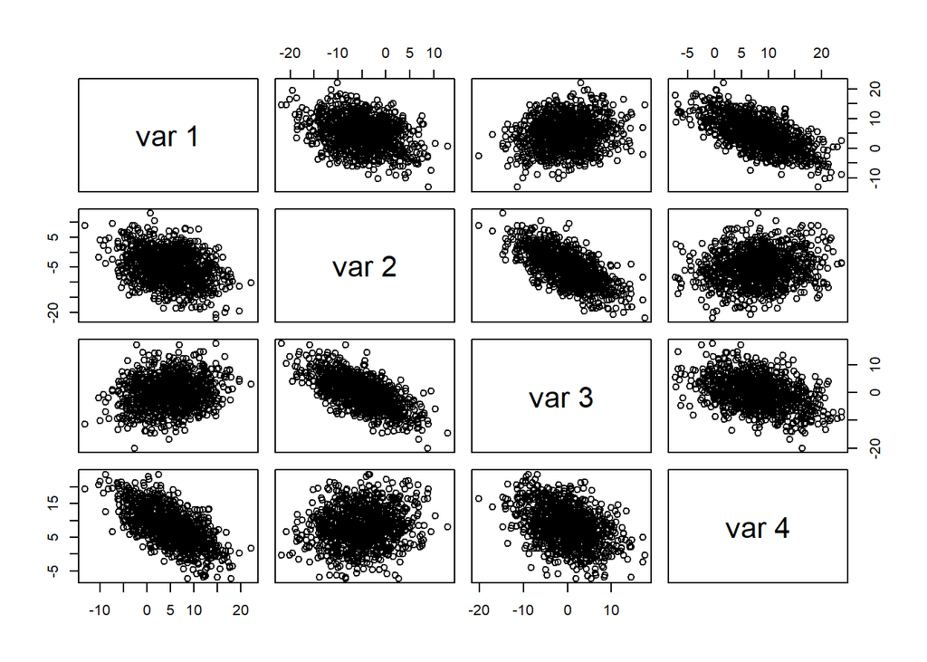

```r
pairs(Y)
```

# Exercise 4

Suppose we want to estimate
$$\theta = \int_0^3 x^2e^{-x}dx.$$
This is not a super-difficult integral to calculate analytically; we get $\theta=2 - 17e^{-3} \approx 1.1536$. But for this problem, we want to try a couple different Monte Carlo approximations. (Suppose you forgot how to integrate by parts and you only need a quick approximation.)

**Part (a)** Compute a Monte Carlo estimate $\hat{\theta}$ by sampling 10,000 observations from ${\rm Unif}(0,3)$. Use `set.seed(440)` to make your answer exactly reproducible.

**Hint:** If $X\sim\mbox{Unif}(0,3)$, what function $g(t)$ makes $\theta=E[g(X)]$? You’ll need to know the density function of $X$ to answer this question.

**Part (b)** Find another Monte Carlo estimate $\tilde{\theta}$ by sampling 10,000 observations from a gamma distribution with shape parameter 3 and scale parameter 1. Use `rgamma` in `R` and, as in part (a), use `set.seed(440)` to make your answer exactly reproducible.

**Hint:** Use the same hint as in part (a). For a gamma density with shape parameter 3, you’ll need to know that $\Gamma(3)=2$.

**Part (c)** Both of your answers from (a) and (b) will be sample means. Recall that the standard error of a sample mean is $s/\sqrt{n}$, where $s$ is the sample standard deviation and $n$ is the sample size. Calculate the standard error for both $\hat{\theta}$ and $\tilde{\theta}$.

**Part (d)** Not all Monte Carlo estimators of the same quantity are equivalent. One way to compare is using mean squared error (MSE), which equals variance plus the square of bias. Since a sample mean is an unbiased estimator of its true mean, in this case MSE reduces to variance. Since standard error is the square root of sample variance, what do your answers from Part (c) suggest is the more precise estimator of $\theta$: $\hat{\theta}$ or $\tilde{\theta}$?

### Answer

**Part a**

We want to sample from $\mbox{Unif}(0,3)$ the density function for this distribution will be $f(x) = \frac13I_{0<x<3}$

$\theta = E[g(x)] = \int_0^3 g(x)f(x)dx$

because we know what f(x) is, we know that $g(x) = 3x^2e^{-x}$

So then the estimator for the monte carlo integration is $\hat{\theta} = \frac1n \sum_{i=1}^n 3X_i^2e^{-X_i}$

```r
set.seed(440)

X <- runif(10000, min = 0, max = 3)

theta_hat <- mean(3 * X^2 * exp(-X))

print("approximation:")
```

```
## [1] "approximation:"
```

```r
theta_hat
```

```
## [1] 1.157937
```

**Part b**

Now we are using a Gamma(3, 1) distribution to sample from

We want to sample from $\mbox{Gamma}(1,3)$ the density function for this distribution will be $f(x) = \frac{\lambda^\alpha}{\Gamma(\alpha)}x^{\alpha -1} = \frac12x^2e^{-x}$

Then we can find out what g(x) is: $g(x) = 2$

So then the estimator for the monte carlo integration is $\tilde{\theta} = \frac1n \sum_{i=1}^n 2$

```r
set.seed(440)

G <- rgamma(10000, shape = 3, scale = 1)
bounded_G <- G[G < 3]

# Compute Monte Carlo estimate
theta_til <- mean(2)

# we only need to take the expectation of g(x) which is just 2

print("approximation: ")
```

```
## [1] "approximation: "
```

```r
theta_til
```

```
## [1] 2
```

**Part c**

```r
se_theta_hat <- sd(3 * X^2 * exp(-X)) / sqrt(10000)

# Compute standard deviation and standard error for theta_til
se_theta_til <- sd(rep(2,10000)) / sqrt(10000)  # Since all values are 2, sd = 0

# Print results
print(se_theta_hat)
```

```
## [1] 0.005244469
```

```r
print(se_theta_til)
```

```
## [1] 0
```

**Part d**

MSE is Variance + Bias$^2$ but since bias is 0 in this scenario, MSE will be just Variance

```r
mse_theta_hat <- se_theta_hat^2
mse_theta_til <- se_theta_til^2

print("MSE of Uniform Sampling Estimate")
```

```
## [1] "MSE of Uniform Sampling Estimate"
```

```r
mse_theta_hat
```

```
## [1] 2.750446e-05
```

```r
print("MSE of Gamma Sampling Estimate:")
```

```
## [1] "MSE of Gamma Sampling Estimate:"
```

```r
mse_theta_til
```

```
## [1] 0
```

This means that the Monte Carlo estimate using the Gamma distribution is better than the other estimator.